# Neural Network Project

PART A

1. Data import and Understanding

```python
# Importing required libraries
import numpy as np
import pandas as pd
import seaborn as sns
import matplotlib.pyplot as plt
%matplotlib inline
from sklearn.model_selection import train_test_split
import imblearn
from sklearn.preprocessing import LabelEncoder
from scipy.stats import zscore
from sklearn.cluster import KMeans
from sklearn.preprocessing import StandardScaler
from scipy.spatial.distance import cdist
from scipy.cluster.hierarchy import dendrogram, linkage, fcluster
from sklearn.metrics import silhouette_samples, silhouette_score
from sklearn import metrics
from sklearn.metrics import classification_report, accuracy_score, recall_score, confusion_matrix, roc_curve, roc_auc_score
from sklearn.model_selection import GridSearchCV
import sklearn.svm
from sklearn.svm import SVC
from sklearn.decomposition import PCA
import warnings
warnings.filterwarnings("ignore")
import tensorflow as tf
from tensorflow import keras
from tensorflow.keras.utils import to_categorical
from tensorflow.keras import losses
from tensorflow.keras import optimizers
from tensorflow.keras import Sequential
from tensorflow.keras.layers import Dense, Activation, LeakyReLU
from tensorflow.keras.layers import Dropout, BatchNormalization
import random
from tensorflow.keras import backend
```

```
WARNING:tensorflow:From C:\Users\ruhee\anaconda3\lib\site-packages\keras\src\losses.py:2976: The name tf.losses.sparse_softmax_cross_entropy is deprecated. Please use tf.compat.v1.losses.sparse_softmax_cross_entropy instead.
```

```python
# Reading the signals dataframe
df = pd.read_csv("C:/Users/ruhee/OneDrive/Desktop/AIML/Introduction to Neural Network and Deep Learning/Part-+1%2C2%263+-+Signal.csv")
df.head()
```

|  | Parameter 1 | Parameter 2 | Parameter 3 | Parameter 4 | Parameter 5 | Parameter 6 | Parameter 7 | Parameter 8 | Parameter 9 | Parameter 10 | Parameter 11 | Signal_Strength |
| --- | --- | --- | --- | --- | --- | --- | --- | --- | --- | --- | --- | --- |
| 0 | 7.4 | 0.70 | 0.00 | 1.9 | 0.076 | 11.0 | 34.0 | 0.9978 | 3.51 | 0.56 | 9.4 | 5 |
| 1 | 7.8 | 0.88 | 0.00 | 2.6 | 0.098 | 25.0 | 67.0 | 0.9968 | 3.20 | 0.68 | 9.8 | 5 |
| 2 | 7.8 | 0.76 | 0.04 | 2.3 | 0.092 | 15.0 | 54.0 | 0.9970 | 3.26 | 0.65 | 9.8 | 5 |
| 3 | 11.2 | 0.28 | 0.56 | 1.9 | 0.075 | 17.0 | 60.0 | 0.9980 | 3.16 | 0.58 | 9.8 | 6 |
| 4 | 7.4 | 0.70 | 0.00 | 1.9 | 0.076 | 11.0 | 34.0 | 0.9978 | 3.51 | 0.56 | 9.4 | 5 |

```python
df.shape
```

```
(1599, 12)
```

```python
df.info()
```

```
<class 'pandas.core.frame.DataFrame'>
RangeIndex: 1599 entries, 0 to 1598
Data columns (total 12 columns):
 #   Column           Non-Null Count  Dtype
---  ------           --------------  -----
 0   Parameter 1      1599 non-null   float64
 1   Parameter 2      1599 non-null   float64
 2   Parameter 3      1599 non-null   float64
 3   Parameter 4      1599 non-null   float64
 4   Parameter 5      1599 non-null   float64
 5   Parameter 6      1599 non-null   float64
 6   Parameter 7      1599 non-null   float64
 7   Parameter 8      1599 non-null   float64
 8   Parameter 9      1599 non-null   float64
 9   Parameter 10     1599 non-null   float64
 10  Parameter 11     1599 non-null   float64
 11  Signal_Strength  1599 non-null   int64
dtypes: float64(11), int64(1)
memory usage: 150.0 KB
```

There are no missing values in the dataframe.

```python
# Percentage of missing values for each attribute
print(df.isnull().sum() * 100 / len(df))
```

```
Parameter 1        0.0
Parameter 2        0.0
Parameter 3        0.0
Parameter 4        0.0
Parameter 5        0.0
Parameter 6        0.0
Parameter 7        0.0
Parameter 8        0.0
Parameter 9        0.0
Parameter 10       0.0
Parameter 11       0.0
Signal_Strength    0.0
dtype: float64
```

```python
df.describe().T
```

|  | count | mean | std | min | 25% | 50% | 75% | max |
| --- | --- | --- | --- | --- | --- | --- | --- | --- |
| Parameter 1 | 1599.0 | 8.319637 | 1.741096 | 4.60000 | 7.1000 | 7.90000 | 9.200000 | 15.90000 |
| Parameter 2 | 1599.0 | 0.527821 | 0.179060 | 0.12000 | 0.3900 | 0.52000 | 0.640000 | 1.58000 |
| Parameter 3 | 1599.0 | 0.270976 | 0.194801 | 0.00000 | 0.0900 | 0.26000 | 0.420000 | 1.00000 |
| Parameter 4 | 1599.0 | 2.538806 | 1.409928 | 0.90000 | 1.9000 | 2.20000 | 2.600000 | 15.50000 |
| Parameter 5 | 1599.0 | 0.087467 | 0.047065 | 0.01200 | 0.0700 | 0.07900 | 0.090000 | 0.61100 |
| Parameter 6 | 1599.0 | 15.874922 | 10.460157 | 1.00000 | 7.0000 | 14.00000 | 21.000000 | 72.00000 |
| Parameter 7 | 1599.0 | 46.467792 | 32.895324 | 6.00000 | 22.0000 | 38.00000 | 62.000000 | 289.00000 |
| Parameter 8 | 1599.0 | 0.996747 | 0.001887 | 0.99007 | 0.9956 | 0.99675 | 0.997835 | 1.00369 |
| Parameter 9 | 1599.0 | 3.311113 | 0.154386 | 2.74000 | 3.2100 | 3.31000 | 3.400000 | 4.01000 |
| Parameter 10 | 1599.0 | 0.658149 | 0.169507 | 0.33000 | 0.5500 | 0.62000 | 0.730000 | 2.00000 |
| Parameter 11 | 1599.0 | 10.422983 | 1.065668 | 8.40000 | 9.5000 | 10.20000 | 11.100000 | 14.90000 |
| Signal_Strength | 1599.0 | 5.636023 | 0.807569 | 3.00000 | 5.0000 | 6.00000 | 6.000000 | 8.00000 |

```python
# Checking for duplicate values
df.duplicated().sum()
```

```
240
```

```python
# Replacing duplicate entries with median
df.fillna(df.median(), inplace=True)
df.shape
```

```
(1599, 12)
```

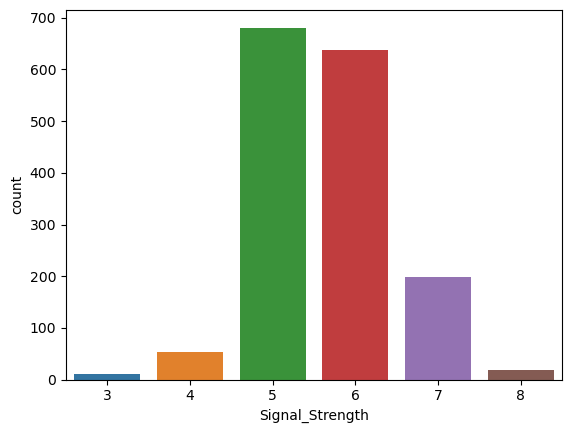

```python
# Visualizing distribution of target variable
sns.countplot(df['Signal_Strength']);
```

Class 5 has the highest count.

```python
correlation = df.corr()
correlation
```

|  | Parameter 1 | Parameter 2 | Parameter 3 | Parameter 4 | Parameter 5 | Parameter 6 | Parameter 7 | Parameter 8 | Parameter 9 | Parameter 10 | Parameter 11 | Signal_Strength |
| --- | --- | --- | --- | --- | --- | --- | --- | --- | --- | --- | --- | --- |
| Parameter 1 | 1.000000 | -0.256131 | 0.671703 | 0.114777 | 0.093705 | -0.153794 | -0.113181 | 0.668047 | -0.682978 | 0.183006 | -0.061668 | 0.124052 |
| Parameter 2 | -0.256131 | 1.000000 | -0.552496 | 0.001918 | 0.061298 | -0.010504 | 0.076470 | 0.022026 | 0.234937 | -0.260987 | -0.202288 | -0.390558 |
| Parameter 3 | 0.671703 | -0.552496 | 1.000000 | 0.143577 | 0.203823 | -0.060978 | 0.035533 | 0.364947 | -0.541904 | 0.312770 | 0.109903 | 0.226373 |
| Parameter 4 | 0.114777 | 0.001918 | 0.143577 | 1.000000 | 0.055610 | 0.187049 | 0.203028 | 0.355283 | -0.085652 | 0.005527 | 0.042075 | 0.013732 |
| Parameter 5 | 0.093705 | 0.061298 | 0.203823 | 0.055610 | 1.000000 | 0.005562 | 0.047400 | 0.200632 | -0.265026 | 0.371260 | -0.221141 | -0.128907 |
| Parameter 6 | -0.153794 | -0.010504 | -0.060978 | 0.187049 | 0.005562 | 1.000000 | 0.667666 | -0.021946 | 0.070377 | 0.051658 | -0.069408 | -0.050656 |
| Parameter 7 | -0.113181 | 0.076470 | 0.035533 | 0.203028 | 0.047400 | 0.667666 | 1.000000 | 0.071269 | -0.066495 | 0.042947 | -0.205654 | -0.185100 |
| Parameter 8 | 0.668047 | 0.022026 | 0.364947 | 0.355283 | 0.200632 | -0.021946 | 0.071269 | 1.000000 | -0.341699 | 0.148506 | -0.496180 | -0.174919 |
| Parameter 9 | -0.682978 | 0.234937 | -0.541904 | -0.085652 | -0.265026 | 0.070377 | -0.066495 | -0.341699 | 1.000000 | -0.196648 | 0.205633 | -0.057731 |
| Parameter 10 | 0.183006 | -0.260987 | 0.312770 | 0.005527 | 0.371260 | 0.051658 | 0.042947 | 0.148506 | -0.196648 | 1.000000 | 0.093595 | 0.251397 |
| Parameter 11 | -0.061668 | -0.202288 | 0.109903 | 0.042075 | -0.221141 | -0.069408 | -0.205654 | -0.496180 | 0.205633 | 0.093595 | 1.000000 | 0.476166 |
| Signal_Strength | 0.124052 | -0.390558 | 0.226373 | 0.013732 | -0.128907 | -0.050656 | -0.185100 | -0.174919 | -0.057731 | 0.251397 | 0.476166 | 1.000000 |

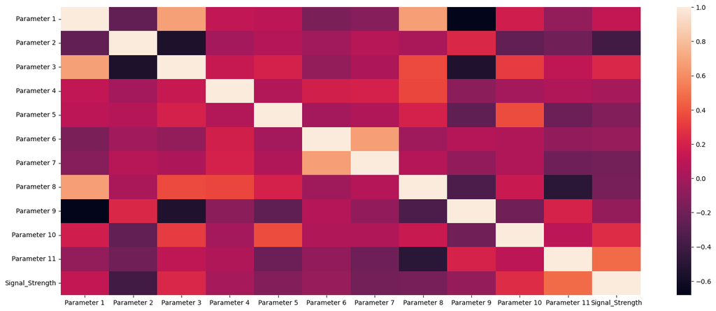

```python
plt.subplots(figsize = (20,8))
sns.heatmap(correlation)
plt.show()
```

1. Data Processing

```python
# Separating the target variable and splitting the data into X and y
X = df.drop("Signal_Strength", 1)
y = df["Signal_Strength"]
```

```python
# Splitting the data into train and test with 70:30 proportion
X_train, X_test, y_train, y_test = train_test_split(X, y, train_size = 0.7, random_state = 10)
```

```python
# Printing shape of all the 4 variables
print(X_train.shape)
print(X_test.shape)
print(y_train.shape)
print(y_test.shape)
```

```
(1119, 11)
(480, 11)
(1119,)
(480,)
```

Train and test data are in sync.

```python
# Normalising the train and test data using Standard Scaler
X_train_s = StandardScaler().fit_transform(X_train)
X_test_s = StandardScaler().fit_transform(X_test)
```

```python
# Converting to "One-Hot" vectors
y_train = to_categorical(y_train)
y_test = to_categorical(y_test)
```

1. Model Training & Evaluation using Neural Network

```python
backend.clear_session()
np.random.seed(42)
import random
random.seed(42)
tf.random.set_seed(42)
```

```
WARNING:tensorflow:From C:\Users\ruhee\anaconda3\lib\site-packages\keras\src\backend.py:277: The name tf.reset_default_graph is deprecated. Please use tf.compat.v1.reset_default_graph instead.
```

```python
# Designing a model
model = Sequential()
# Input Layer
model.add(Dense(128, activation = 'relu', kernel_initializer = 'normal',input_dim = X_train_s.shape[1]))
# Adding the hidden layers
model.add(Dense(64, kernel_initializer = 'normal'))
model.add(Dense(32, kernel_initializer = 'normal'))
model.add(LeakyReLU(alpha = 0.1))
model.add(Dense(16, kernel_initializer = 'normal'))
model.add(LeakyReLU(alpha = 0.1))
# Adding the Output Layer
model.add(Dense(9, kernel_initializer = 'normal', activation = 'softmax'))
# Compiling the model
model.compile(loss = 'mean_absolute_error', optimizer = 'adam', metrics = ['accuracy'])
model.summary()
```

```
WARNING:tensorflow:From C:\Users\ruhee\anaconda3\lib\site-packages\keras\src\optimizers\__init__.py:309: The name tf.train.Optimizer is deprecated. Please use tf.compat.v1.train.Optimizer instead.

Model: "sequential"
_________________________________________________________________
 Layer (type)                Output Shape              Param #
=================================================================
 dense (Dense)               (None, 128)               1536

 dense_1 (Dense)             (None, 64)                8256

 dense_2 (Dense)             (None, 32)                2080

 leaky_re_lu (LeakyReLU)     (None, 32)                0

 dense_3 (Dense)             (None, 16)                528

 leaky_re_lu_1 (LeakyReLU)   (None, 16)                0

 dense_4 (Dense)             (None, 9)                 153

=================================================================
Total params: 12553 (49.04 KB)
Trainable params: 12553 (49.04 KB)
Non-trainable params: 0 (0.00 Byte)
_________________________________________________________________
```

```python
# Training the model
EPOCH = 400
history = model.fit(X_train_s, y_train, validation_data = (X_test_s,y_test), epochs = EPOCH, batch_size = 200)
```

```
WARNING:tensorflow:From C:\Users\ruhee\anaconda3\lib\site-packages\keras\src\utils\tf_utils.py:492: The name tf.ragged.RaggedTensorValue is deprecated. Please use tf.compat.v1.ragged.RaggedTensorValue instead.

WARNING:tensorflow:From C:\Users\ruhee\anaconda3\lib\site-packages\keras\src\engine\base_layer_utils.py:384: The name tf.executing_eagerly_outside_functions is deprecated. Please use tf.compat.v1.executing_eagerly_outside_functions instead.
```

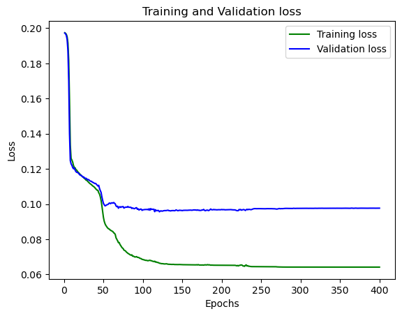

```python
# Plotting a graph for Epochs v/s Training Loss and Validation Loss
loss_train = history.history['loss']
loss_val = history.history['val_loss']
epochs = range(1, EPOCH + 1)
plt.plot(epochs, loss_train, 'g', label = 'Training loss')
plt.plot(epochs, loss_val, 'b', label = 'Validation loss')
plt.title('Training and Validation loss')
plt.xlabel('Epochs')
plt.ylabel('Loss')
plt.legend()
plt.show()
```

Validation loss is higher than the training loss.

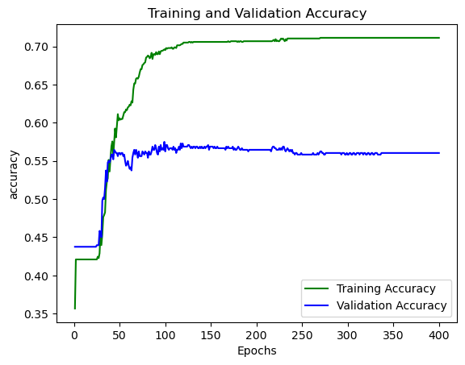

```python
# Plotting a graph for Epochs v/s Training Accuracy and Validation Accuracy
accuracy_train = history.history['accuracy']
accuracy_validation = history.history['val_accuracy']
epochs = range(1, EPOCH + 1)
plt.plot(epochs, accuracy_train, 'g', label = 'Training Accuracy')
plt.plot(epochs, accuracy_validation, 'b', label = 'Validation Accuracy')
plt.title('Training and Validation Accuracy')
plt.xlabel('Epochs')
plt.ylabel('accuracy')
plt.legend()
plt.show()
```

Validation accuracy is lower than the training accuracy.

```python
# Final evaluation of the model
scores = model.evaluate(X_test_s, y_test)
print("Loss:", scores[0])
print("Accuracy:", scores[1])
```

```
Loss: 0.09767515957355499
Accuracy: 0.5604166388511658
```

```python
backend.clear_session()
np.random.seed(42)
import random
random.seed(42)
tf.random.set_seed(42)
```

```python
# Adding Batch Normalization to try to improve the model
model2 = Sequential()
# Input Layer
model2.add(Dense(128, activation = 'relu', kernel_initializer = 'normal', input_dim = X_train_s.shape[1]))
model2.add(BatchNormalization())

# Adding the hidden layers
model2.add(Dense(64, kernel_initializer = 'normal'))
model2.add(LeakyReLU(alpha = 0.1))
model2.add(BatchNormalization())

model2.add(Dense(32, kernel_initializer = 'normal'))
model2.add(LeakyReLU(alpha = 0.1))
model2.add(BatchNormalization())

model2.add(Dense(16, kernel_initializer = 'normal'))
model2.add(LeakyReLU(alpha = 0.1))
model2.add(BatchNormalization())

# Adding the Output Layer
model2.add(Dense(9, kernel_initializer = 'normal', activation = 'softmax'))

# Compiling the model
model2.compile(loss = 'mean_absolute_error', optimizer = 'adam', metrics = ['accuracy'])
model2.summary()
```

```
Model: "sequential"
_________________________________________________________________
 Layer (type)                Output Shape              Param #
=================================================================
 dense (Dense)               (None, 128)               1536

 batch_normalization (Batch  (None, 128)               512
 Normalization)

 dense_1 (Dense)             (None, 64)                8256

 leaky_re_lu (LeakyReLU)     (None, 64)                0

 batch_normalization_1 (Bat  (None, 64)                256
 chNormalization)

 dense_2 (Dense)             (None, 32)                2080

 leaky_re_lu_1 (LeakyReLU)   (None, 32)                0

 batch_normalization_2 (Bat  (None, 32)                128
 chNormalization)

 dense_3 (Dense)             (None, 16)                528

 leaky_re_lu_2 (LeakyReLU)   (None, 16)                0

 batch_normalization_3 (Bat  (None, 16)                64
 chNormalization)

 dense_4 (Dense)             (None, 9)                 153

=================================================================
Total params: 13513 (52.79 KB)
Trainable params: 13033 (50.91 KB)
Non-trainable params: 480 (1.88 KB)
_________________________________________________________________
```

```python
# Training the model
EPOCH = 400
history2 = model2.fit(X_train_s, y_train, validation_data = (X_test_s,y_test), epochs = EPOCH, batch_size = 200)
```

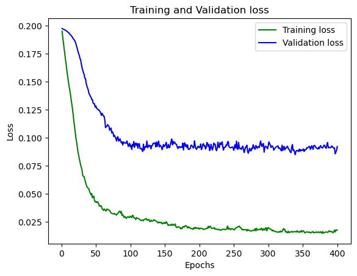

```python
# Plotting a graph for Epochs v/s Training Loss and Validation Loss
loss_train = history2.history['loss']
loss_val = history2.history['val_loss']
epochs = range(1, EPOCH + 1)
plt.plot(epochs, loss_train, 'g', label = 'Training loss')
plt.plot(epochs, loss_val, 'b', label = 'Validation loss')
plt.title('Training and Validation loss')
plt.xlabel('Epochs')
plt.ylabel('Loss')
plt.legend()
plt.show()
```

Validation loss is higher than the training loss.

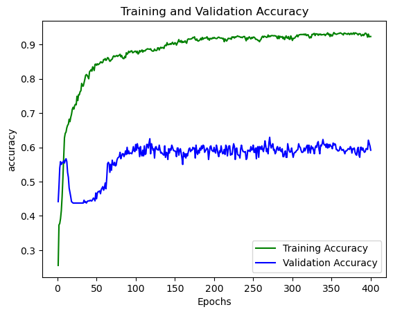

```python
# Plotting a graph for Epochs v/s Training Accuracy and Validation Accuracy
accuracy_train = history2.history['accuracy']
accuracy_validation = history2.history['val_accuracy']
epochs = range(1, EPOCH + 1)
plt.plot(epochs, accuracy_train, 'g', label = 'Training Accuracy')
plt.plot(epochs, accuracy_validation, 'b', label = 'Validation Accuracy')
plt.title('Training and Validation Accuracy')
plt.xlabel('Epochs')
plt.ylabel('accuracy')
plt.legend()
plt.show()
```

Validation accuracy is lower than the training accuracy.

```python
# Final evaluation of the model
scores = model2.evaluate(X_test_s, y_test)
print("Loss:", scores[0])
print("Accuracy:", scores[1])
```

```
Loss: 0.09221890568733215
Accuracy: 0.5916666388511658
```

Insights: Test accuracy has improved from 56.04% to 59.17%. Test loss has also improved from 0.098 to 0.092.

Overall 'model2' had better acccuracy and loss curves when compared to 'model'.

PART B

1. Data Import and Exploration

```python
import h5py
```

```python
# Read the h5 file and assigning it to a variable
h5f = h5py.File("C:/Users/ruhee/OneDrive/Desktop/AIML/Introduction to Neural Network and Deep Learning/Autonomous_Vehicles_SVHN_single_grey1 (1).h5")
```

```python
# Printing the keys
h5f.keys()
```

```
<KeysViewHDF5 ['X_test', 'X_train', 'X_val', 'y_test', 'y_train', 'y_val']>
```

```python
# The data is already split into train, validation and test data
X_train = h5f['X_train'][:]
y_train = h5f['y_train'][:]
X_val = h5f['X_val'][:]
y_val = h5f['y_val'][:]
X_test = h5f['X_test'][:]
y_test = h5f['y_test'][:]
```

```python
# Combining the train and validation data to train data
X_train = np.concatenate((X_train, X_val), axis = 0)
y_train = np.concatenate((y_train, y_val), axis = 0)
```

1. Data Visualisation and preprocessing

```python
# Checking the size of the data
print(f'Size of X_train is {X_train.shape}')
print(f'Size of y_train is {y_train.shape}')
print(f'Size of X_test is {X_test.shape}')
print(f'Size of y_test is {y_test.shape}')
```

```
Size of X_train is (102000, 32, 32)
Size of y_train is (102000,)
Size of X_test is (18000, 32, 32)
Size of y_test is (18000,)
```

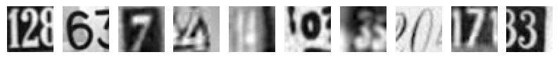

```
Label for each of the above images: [2 6 7 4 4 0 3 0 7 3]
```

```python
# Visualizing the first 10 images in the train data and the corresponding labels
plt.figure(figsize = (10, 1))
for i in range(10):
    plt.subplot(1, 10, i + 1)
    plt.imshow(X_train[i], cmap = "gray")
    plt.axis('off')
plt.show()
print('Label for each of the above images: %s' % (y_train[0:10]))
```

```python
# Reshaping the images to flatten them
image_vector_size = 32 * 32
X_train = X_train.reshape(X_train.shape[0], image_vector_size)
X_test = X_test.reshape(X_test.shape[0], image_vector_size)
```

```python
print(f'Min value for Train = {X_train.min()}, Test = {X_test.min()}')
print(f'Max value for Train = {X_train.max()}, Test = {X_test.max()}')
```

```
Min value for Train = 0.0, Test = 0.0
Max value for Train = 254.97450256347656, Test = 254.97450256347656
```

```python
# Normalizing the pixel values
max_value = X_train.max() # Max value of train and test data is same
X_train = X_train / max_value
X_test = X_test / max_value

print('Training set', X_train.shape, y_train.shape)
print('Test set', X_test.shape, y_test.shape)
```

```
Training set (102000, 1024) (102000,)
Test set (18000, 1024) (18000,)
```

```python
# Converting to "One-Hot" vectors
y_train = to_categorical(y_train)
y_test = to_categorical(y_test)
```

```python
num_classes = y_test.shape[1]
print("The total number of classes in the dataset are:", num_classes)
```

```
The total number of classes in the dataset are: 10
```

1. Model Training & Evaluation using Neural Network

```python
backend.clear_session()
np.random.seed(42)
import random
random.seed(42)
tf.random.set_seed(42)
```

```python
# Designing a model
image_size = 32 * 32

Model = Sequential()
Model.add(Dense(256, activation = 'relu', kernel_initializer = 'he_uniform',input_shape = (image_size,)))
Model.add(Dense(64, activation = 'relu', kernel_initializer = 'he_uniform'))
Model.add(Dense(64, activation = 'relu', kernel_initializer = 'he_uniform'))
Model.add(Dense(32, activation = 'relu', kernel_initializer = 'he_uniform'))
Model.add(Dense(num_classes, activation = 'softmax'))
```

```python
Model.summary()
```

```
Model: "sequential"
_________________________________________________________________
 Layer (type)                Output Shape              Param #
=================================================================
 dense (Dense)               (None, 256)               262400

 dense_1 (Dense)             (None, 64)                16448

 dense_2 (Dense)             (None, 64)                4160

 dense_3 (Dense)             (None, 32)                2080

 dense_4 (Dense)             (None, 10)                330

=================================================================
Total params: 285418 (1.09 MB)
Trainable params: 285418 (1.09 MB)
Non-trainable params: 0 (0.00 Byte)
_________________________________________________________________
```

```python
# Compiling the model
adam = optimizers.Adam(learning_rate = 1e-3)
Model.compile(loss = losses.categorical_crossentropy, optimizer = adam, metrics = ['accuracy'])
```

```python
from tensorflow.keras.callbacks import ModelCheckpoint, ReduceLROnPlateau
checkpoint = ModelCheckpoint('model_weights.h5', monitor = 'val_accuracy',
                             save_weights_only = True, mode = 'max', verbose = 1)
reduce_learning_rate = ReduceLROnPlateau(monitor = 'val_loss', factor = 0.1, patience = 2,
                                         min_learning_rate = 0.00001, model = 'auto')
callbacks = [checkpoint, reduce_learning_rate]
```

```python
# Training the model
History = Model.fit(X_train, y_train, validation_split = 0.2, epochs = 50, batch_size = 150, verbose = 2, callbacks = callbacks)
```

```
Epoch 1: saving model to model_weights.h5
544/544 - 6s - loss: 2.0965 - accuracy: 0.2224 - val_loss: 1.5881 - val_accuracy: 0.4418 - lr: 0.0010 - 6s/epoch - 11ms/step

Epoch 2: saving model to model_weights.h5
544/544 - 4s - loss: 1.4430 - accuracy: 0.5178 - val_loss: 1.1846 - val_accuracy: 0.6099 - lr: 0.0010 - 4s/epoch - 8ms/step

Epoch 3: saving model to model_weights.h5
544/544 - 4s - loss: 1.2544 - accuracy: 0.5937 - val_loss: 1.0634 - val_accuracy: 0.6620 - lr: 0.0010 - 4s/epoch - 7ms/step

Epoch 4: saving model to model_weights.h5
544/544 - 4s - loss: 1.1337 - accuracy: 0.6419 - val_loss: 0.9301 - val_accuracy: 0.7153 - lr: 0.0010 - 4s/epoch - 8ms/step

Epoch 5: saving model to model_weights.h5
544/544 - 4s - loss: 1.0444 - accuracy: 0.6746 - val_loss: 0.8519 - val_accuracy: 0.7401 - lr: 0.0010 - 4s/epoch - 7ms/step

Epoch 6: saving model to model_weights.h5
544/544 - 4s - loss: 0.9864 - accuracy: 0.6951 - val_loss: 0.8214 - val_accuracy: 0.7470 - lr: 0.0010 - 4s/epoch - 7ms/step

Epoch 7: saving model to model_weights.h5
544/544 - 4s - loss: 0.9337 - accuracy: 0.7129 - val_loss: 0.7548 - val_accuracy: 0.7765 - lr: 0.0010 - 4s/epoch - 7ms/step

Epoch 8: saving model to model_weights.h5
544/544 - 4s - loss: 0.8808 - accuracy: 0.7289 - val_loss: 0.7119 - val_accuracy: 0.7860 - lr: 0.0010 - 4s/epoch - 7ms/step

Epoch 9: saving model to model_weights.h5
544/544 - 4s - loss: 0.8525 - accuracy: 0.7376 - val_loss: 0.7075 - val_accuracy: 0.7851 - lr: 0.0010 - 4s/epoch - 8ms/step

Epoch 10: saving model to model_weights.h5
544/544 - 4s - loss: 0.8161 - accuracy: 0.7487 - val_loss: 0.6713 - val_accuracy: 0.7929 - lr: 0.0010 - 4s/epoch - 7ms/step

Epoch 11: saving model to model_weights.h5
544/544 - 4s - loss: 0.7929 - accuracy: 0.7558 - val_loss: 0.6540 - val_accuracy: 0.8015 - lr: 0.0010 - 4s/epoch - 8ms/step

Epoch 12: saving model to model_weights.h5
544/544 - 4s - loss: 0.7680 - accuracy: 0.7623 - val_loss: 0.6284 - val_accuracy: 0.8073 - lr: 0.0010 - 4s/epoch - 7ms/step

Epoch 13: saving model to model_weights.h5
544/544 - 4s - loss: 0.7472 - accuracy: 0.7700 - val_loss: 0.6086 - val_accuracy: 0.8153 - lr: 0.0010 - 4s/epoch - 7ms/step

Epoch 14: saving model to model_weights.h5
```

[output cut: 94 more lines]

```

Epoch 46: saving model to model_weights.h5
544/544 - 4s - loss: 0.4315 - accuracy: 0.8672 - val_loss: 0.3991 - val_accuracy: 0.8800 - lr: 1.0000e-06 - 4s/epoch - 8ms/step

Epoch 47: saving model to model_weights.h5
544/544 - 5s - loss: 0.4313 - accuracy: 0.8676 - val_loss: 0.3990 - val_accuracy: 0.8806 - lr: 1.0000e-06 - 5s/epoch - 8ms/step

Epoch 48: saving model to model_weights.h5
544/544 - 5s - loss: 0.4313 - accuracy: 0.8674 - val_loss: 0.3990 - val_accuracy: 0.8810 - lr: 1.0000e-06 - 5s/epoch - 9ms/step

Epoch 49: saving model to model_weights.h5
544/544 - 5s - loss: 0.4311 - accuracy: 0.8675 - val_loss: 0.3990 - val_accuracy: 0.8810 - lr: 1.0000e-07 - 5s/epoch - 9ms/step

Epoch 50: saving model to model_weights.h5
544/544 - 4s - loss: 0.4311 - accuracy: 0.8676 - val_loss: 0.3990 - val_accuracy: 0.8809 - lr: 1.0000e-07 - 4s/epoch - 7ms/step
```

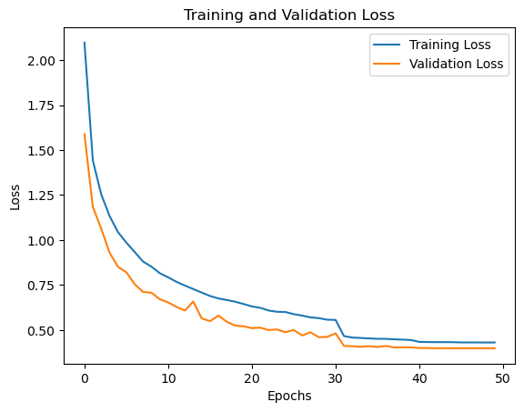

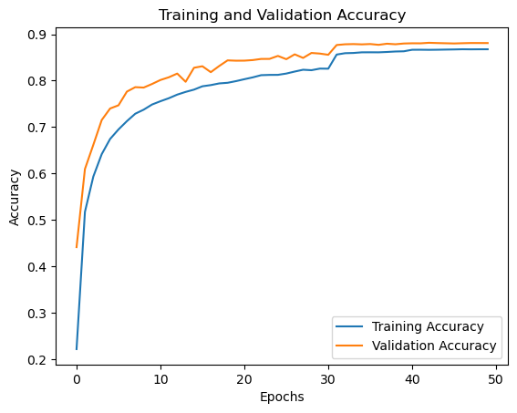

```python
accuracy = History.history['accuracy']
val_accuracy = History.history['val_accuracy']
loss = History.history['loss']
val_loss = History.history['val_loss']
epochs = range(len(accuracy))
# Plotting a graph for Epochs v/s Training Loss and Validation Loss
plt.plot(epochs, loss, label = 'Training Loss')
plt.plot(epochs, val_loss, label = 'Validation Loss')
plt.legend(loc = 'upper right')
plt.title('Training and Validation Loss')
plt.xlabel('Epochs')
plt.ylabel('Loss')
plt.figure()
# Plotting a graph for Epochs v/s Training Accuracy and Validation Accuracy
plt.plot(epochs, accuracy, label = 'Training Accuracy')
plt.plot(epochs, val_accuracy, label = 'Validation Accuracy')
plt.title('Training and Validation Accuracy')
plt.legend(loc = 'lower right')
plt.xlabel('Epochs')
plt.ylabel('Accuracy')
```

Validation loss is lower than training loss. Validation accuracy is higher than training accuracy.

```python
# Final evaluation of the model
scores = Model.evaluate(X_test, y_test)
print("Loss:", scores[0])
print("Accuracy:", scores[1])
```

```
Loss: 0.5152385830879211
Accuracy: 0.8483333587646484
```

```python
backend.clear_session()
np.random.seed(42)
import random
random.seed(42)
tf.random.set_seed(42)
```

```python
# Adding Batch Normalization to try to improve the model
Model2 = Sequential()
Model2.add(Dense(256, activation = 'relu', kernel_initializer = 'he_uniform',input_shape = (image_size,)))
Model2.add(BatchNormalization())
Model2.add(Dense(64, activation = 'relu', kernel_initializer = 'he_uniform'))
Model2.add(BatchNormalization())
Model2.add(Dense(64, activation = 'relu', kernel_initializer = 'he_uniform'))
Model2.add(BatchNormalization())
Model2.add(Dense(32, activation = 'relu', kernel_initializer = 'he_uniform'))
Model2.add(Dense(num_classes, activation = 'softmax'))
```

```python
Model2.summary()
```

```
Model: "sequential"
_________________________________________________________________
 Layer (type)                Output Shape              Param #
=================================================================
 dense (Dense)               (None, 256)               262400

 batch_normalization (Batch  (None, 256)               1024
 Normalization)

 dense_1 (Dense)             (None, 64)                16448

 batch_normalization_1 (Bat  (None, 64)                256
 chNormalization)

 dense_2 (Dense)             (None, 64)                4160

 batch_normalization_2 (Bat  (None, 64)                256
 chNormalization)

 dense_3 (Dense)             (None, 32)                2080

 dense_4 (Dense)             (None, 10)                330

=================================================================
Total params: 286954 (1.09 MB)
Trainable params: 286186 (1.09 MB)
Non-trainable params: 768 (3.00 KB)
_________________________________________________________________
```

```python
# Compiling the model
optimizer = tf.keras.optimizers.Adam(0.001)
Model2.compile(loss = losses.categorical_crossentropy, optimizer = optimizer, metrics = ['accuracy'])
```

```python
History_2 = Model2.fit(X_train, y_train, batch_size = 64, epochs = 50, verbose = 1, validation_split = 0.2)
```

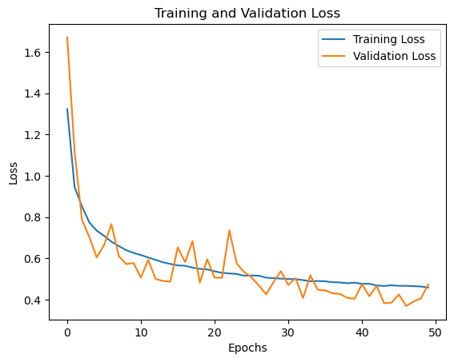

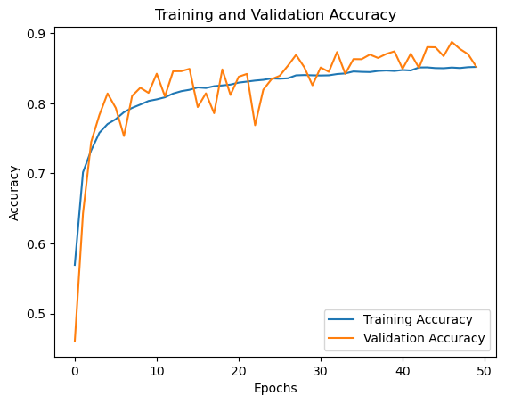

```python
accuracy = History_2.history['accuracy']
val_accuracy = History_2.history['val_accuracy']
loss = History_2.history['loss']
val_loss = History_2.history['val_loss']
epochs = range(len(accuracy))
# Plotting a graph for Epochs v/s Training Loss and Validation Loss
plt.plot(epochs, loss, label = 'Training Loss')
plt.plot(epochs, val_loss, label = 'Validation Loss')
plt.legend(loc = 'upper right')
plt.title('Training and Validation Loss')
plt.xlabel('Epochs')
plt.ylabel('Loss')
plt.figure()
# Plotting a graph for Epochs v/s Training Accuracy and Validation Accuracy
plt.plot(epochs, accuracy, label = 'Training Accuracy')
plt.plot(epochs, val_accuracy, label = 'Validation Accuracy')
plt.title('Training and Validation Accuracy')
plt.legend(loc = 'lower right')
plt.xlabel('Epochs')
plt.ylabel('Accuracy')
```

There is noise in this model.

```python
# Final evaluation of the model
scores = Model2.evaluate(X_test, y_test)
print("Loss:", scores[0])
print("Accuracy:", scores[1])
```

```
Loss: 0.6173790693283081
Accuracy: 0.812166690826416
```

Test accuracy reduced from 84.83% to 81.22%. Loss also increased from 0.515 to 0.617.

Overall the earlier model was better.